# Comprehensive Project: STA 257

We will generate 12 total sinusodal vectors / 2 matrecies for our harmoic seasons.

```r
SIN = COS = matrix(nrow=length(time(csp.tr)),ncol=6)
for(i in 1:6){
  COS[,i]=cos(2*pi*i*time(csp.tr))
  SIN[,i]=sin(2*pi*i*time(csp.tr))
}
```

We will once again, standardize time based on the csp training time series

```r
TIME = (time(csp.tr)-mean(time(csp.tr)))/sd(time(csp.tr))
```

Now to compare both linear models fairly, I will start with the same predictors, but may use stepwise for this model.

```r
csp.tr.har1 = lm(csp.tr~TIME+I(TIME^2)+I(TIME^3)+I(TIME^4)+
                  COS[,1]+SIN[,1]+
                  COS[,2]+SIN[,2]+
                  COS[,3]+SIN[,3]+
                  COS[,4]+SIN[,4]+
                  COS[,5]+SIN[,5]+
                  COS[,6]+SIN[,6])
```

Lets look at the summary and see which predictors to vote off.

```r
summary(csp.tr.har1) # SIN[,6]
```

```
##
## Call:
## lm(formula = csp.tr ~ TIME + I(TIME^2) + I(TIME^3) + I(TIME^4) +
##     COS[, 1] + SIN[, 1] + COS[, 2] + SIN[, 2] + COS[, 3] + SIN[,
##     3] + COS[, 4] + SIN[, 4] + COS[, 5] + SIN[, 5] + COS[, 6] +
##     SIN[, 6])
##
## Residuals:
##      Min       1Q   Median       3Q      Max
## -1.33899 -0.30623 -0.03096  0.28966  0.89527
##
## Coefficients:
##               Estimate Std. Error  t value Pr(>|t|)
## (Intercept)  3.681e+02  4.062e-02 9061.640  < 2e-16 ***
## TIME         1.404e+01  5.434e-02  258.333  < 2e-16 ***
## I(TIME^2)    7.552e-01  8.508e-02    8.876  < 2e-16 ***
## I(TIME^3)   -5.049e-01  2.779e-02  -18.169  < 2e-16 ***
## I(TIME^4)    1.479e-01  3.180e-02    4.649 5.03e-06 ***
## COS[, 1]    -3.994e-01  3.064e-02  -13.034  < 2e-16 ***
## SIN[, 1]    -6.141e-01  3.068e-02  -20.016  < 2e-16 ***
## COS[, 2]    -1.433e-01  3.133e-02   -4.575 7.02e-06 ***
## SIN[, 2]    -1.458e-02  3.080e-02   -0.473    0.636
## COS[, 3]    -1.798e-02  3.064e-02   -0.587    0.558
## SIN[, 3]    -4.229e-02  3.064e-02   -1.380    0.169
## COS[, 4]    -1.808e-02  3.064e-02   -0.590    0.555
## SIN[, 4]     4.006e-03  3.066e-02    0.131    0.896
## COS[, 5]    -1.042e-02  3.064e-02   -0.340    0.734
## SIN[, 5]    -1.896e-03  3.064e-02   -0.062    0.951
## COS[, 6]    -4.075e-03  2.248e-02   -0.181    0.856
## SIN[, 6]     4.500e+08  4.523e+09    0.099    0.921
## ---
## Signif. codes:  0 '***' 0.001 '**' 0.01 '*' 0.05 '.' 0.1 ' ' 1
##
## Residual standard error: 0.3826 on 295 degrees of freedom
## Multiple R-squared:  0.9992, Adjusted R-squared:  0.9992
## F-statistic: 2.314e+04 on 16 and 295 DF,  p-value: < 2.2e-16
```

All the Time predictors seem to be significant, but a lot of the seasonal sinusodal predictors are not.

I will commence with stepwise, and because these can be compared with each other through AIC, I will use that incase we need to compare two fully-significant predictor models.

```r
csp.tr.har2 = lm(csp.tr~TIME+I(TIME^2)+I(TIME^3)+I(TIME^4)+
                  COS[,1]+SIN[,1]+
                  COS[,2]+SIN[,2]+
                  COS[,3]+SIN[,3]+
                  COS[,4]+SIN[,4]+
                  COS[,5]+SIN[,5]+
                  COS[,6])

summary(csp.tr.har2) # SIN[,5]
```

```
##
## Call:
## lm(formula = csp.tr ~ TIME + I(TIME^2) + I(TIME^3) + I(TIME^4) +
##     COS[, 1] + SIN[, 1] + COS[, 2] + SIN[, 2] + COS[, 3] + SIN[,
##     3] + COS[, 4] + SIN[, 4] + COS[, 5] + SIN[, 5] + COS[, 6])
##
## Residuals:
##      Min       1Q   Median       3Q      Max
## -1.34096 -0.30252 -0.03035  0.28907  0.89750
##
## Coefficients:
##               Estimate Std. Error  t value Pr(>|t|)
## (Intercept) 368.095895   0.040552 9077.222  < 2e-16 ***
## TIME         14.036233   0.054196  258.991  < 2e-16 ***
## I(TIME^2)     0.754970   0.084910    8.891  < 2e-16 ***
## I(TIME^3)    -0.504738   0.027712  -18.214  < 2e-16 ***
## I(TIME^4)     0.147931   0.031747    4.660 4.79e-06 ***
## COS[, 1]     -0.399379   0.030589  -13.056  < 2e-16 ***
## SIN[, 1]     -0.614146   0.030629  -20.051  < 2e-16 ***
## COS[, 2]     -0.143982   0.030588   -4.707 3.86e-06 ***
## SIN[, 2]     -0.014273   0.030595   -0.467    0.641
## COS[, 3]     -0.017941   0.030588   -0.587    0.558
## SIN[, 3]     -0.042281   0.030588   -1.382    0.168
## COS[, 4]     -0.018063   0.030588   -0.591    0.555
## SIN[, 4]      0.003901   0.030586    0.128    0.899
## COS[, 5]     -0.010444   0.030588   -0.341    0.733
## SIN[, 5]     -0.001852   0.030585   -0.061    0.952
## COS[, 6]     -0.004671   0.021628   -0.216    0.829
## ---
## Signif. codes:  0 '***' 0.001 '**' 0.01 '*' 0.05 '.' 0.1 ' ' 1
##
## Residual standard error: 0.382 on 296 degrees of freedom
## Multiple R-squared:  0.9992, Adjusted R-squared:  0.9992
## F-statistic: 2.476e+04 on 15 and 296 DF,  p-value: < 2.2e-16
```

```r
csp.tr.har3 = lm(csp.tr~TIME+I(TIME^2)+I(TIME^3)+I(TIME^4)+
                   COS[,1]+SIN[,1]+
                   COS[,2]+SIN[,2]+
                   COS[,3]+SIN[,3]+
                   COS[,4]+SIN[,4]+
                   COS[,5]+
                   COS[,6])

summary(csp.tr.har3) # SIN[,4]
```

```
##
## Call:
## lm(formula = csp.tr ~ TIME + I(TIME^2) + I(TIME^3) + I(TIME^4) +
##     COS[, 1] + SIN[, 1] + COS[, 2] + SIN[, 2] + COS[, 3] + SIN[,
##     3] + COS[, 4] + SIN[, 4] + COS[, 5] + COS[, 6])
##
## Residuals:
##      Min       1Q   Median       3Q      Max
## -1.34094 -0.30136 -0.03035  0.28922  0.89751
##
## Coefficients:
##               Estimate Std. Error  t value Pr(>|t|)
## (Intercept) 368.095896   0.040484 9092.486  < 2e-16 ***
## TIME         14.036226   0.054105  259.427  < 2e-16 ***
## I(TIME^2)     0.754969   0.084768    8.906  < 2e-16 ***
## I(TIME^3)    -0.504733   0.027665  -18.244  < 2e-16 ***
## I(TIME^4)     0.147931   0.031694    4.667 4.62e-06 ***
## COS[, 1]     -0.399379   0.030537  -13.078  < 2e-16 ***
## SIN[, 1]     -0.614146   0.030577  -20.085  < 2e-16 ***
## COS[, 2]     -0.143982   0.030537   -4.715 3.72e-06 ***
## SIN[, 2]     -0.014273   0.030543   -0.467    0.641
## COS[, 3]     -0.017940   0.030537   -0.588    0.557
## SIN[, 3]     -0.042281   0.030537   -1.385    0.167
## COS[, 4]     -0.018063   0.030537   -0.592    0.555
## SIN[, 4]      0.003901   0.030535    0.128    0.898
## COS[, 5]     -0.010444   0.030537   -0.342    0.733
## COS[, 6]     -0.004671   0.021592   -0.216    0.829
## ---
## Signif. codes:  0 '***' 0.001 '**' 0.01 '*' 0.05 '.' 0.1 ' ' 1
##
## Residual standard error: 0.3814 on 297 degrees of freedom
## Multiple R-squared:  0.9992, Adjusted R-squared:  0.9992
## F-statistic: 2.662e+04 on 14 and 297 DF,  p-value: < 2.2e-16
```

```r
csp.tr.har4 = lm(csp.tr~TIME+I(TIME^2)+I(TIME^3)+I(TIME^4)+
                   COS[,1]+SIN[,1]+
                   COS[,2]+SIN[,2]+
                   COS[,3]+SIN[,3]+
                   COS[,4]+
                   COS[,5]+
                   COS[,6])

summary(csp.tr.har4) # COS[,6]
```

```
##
## Call:
## lm(formula = csp.tr ~ TIME + I(TIME^2) + I(TIME^3) + I(TIME^4) +
##     COS[, 1] + SIN[, 1] + COS[, 2] + SIN[, 2] + COS[, 3] + SIN[,
##     3] + COS[, 4] + COS[, 5] + COS[, 6])
##
## Residuals:
##      Min       1Q   Median       3Q      Max
## -1.34101 -0.29977 -0.03038  0.28752  0.89747
##
## Coefficients:
##               Estimate Std. Error  t value Pr(>|t|)
## (Intercept) 368.095895   0.040417 9107.530  < 2e-16 ***
## TIME         14.036257   0.054015  259.859  < 2e-16 ***
## I(TIME^2)     0.754972   0.084627    8.921  < 2e-16 ***
## I(TIME^3)    -0.504757   0.027619  -18.276  < 2e-16 ***
## I(TIME^4)     0.147930   0.031642    4.675 4.46e-06 ***
## COS[, 1]     -0.399380   0.030487  -13.100  < 2e-16 ***
## SIN[, 1]     -0.614148   0.030527  -20.118  < 2e-16 ***
## COS[, 2]     -0.143983   0.030486   -4.723 3.59e-06 ***
## SIN[, 2]     -0.014274   0.030493   -0.468    0.640
## COS[, 3]     -0.017941   0.030486   -0.588    0.557
## SIN[, 3]     -0.042282   0.030486   -1.387    0.167
## COS[, 4]     -0.018064   0.030486   -0.593    0.554
## COS[, 5]     -0.010445   0.030486   -0.343    0.732
## COS[, 6]     -0.004672   0.021556   -0.217    0.829
## ---
## Signif. codes:  0 '***' 0.001 '**' 0.01 '*' 0.05 '.' 0.1 ' ' 1
##
## Residual standard error: 0.3807 on 298 degrees of freedom
## Multiple R-squared:  0.9992, Adjusted R-squared:  0.9992
## F-statistic: 2.876e+04 on 13 and 298 DF,  p-value: < 2.2e-16
```

```r
csp.tr.har5 = lm(csp.tr~TIME+I(TIME^2)+I(TIME^3)+I(TIME^4)+
                   COS[,1]+SIN[,1]+
                   COS[,2]+SIN[,2]+
                   COS[,3]+SIN[,3]+
                   COS[,4]+
                   COS[,5])

summary(csp.tr.har5) # COS[,5]
```

```
##
## Call:
## lm(formula = csp.tr ~ TIME + I(TIME^2) + I(TIME^3) + I(TIME^4) +
##     COS[, 1] + SIN[, 1] + COS[, 2] + SIN[, 2] + COS[, 3] + SIN[,
##     3] + COS[, 4] + COS[, 5])
##
## Residuals:
##      Min       1Q   Median       3Q      Max
## -1.34554 -0.29510 -0.02633  0.28643  0.89288
##
## Coefficients:
##              Estimate Std. Error  t value Pr(>|t|)
## (Intercept) 368.09590    0.04035 9122.080  < 2e-16 ***
## TIME         14.03619    0.05393  260.277  < 2e-16 ***
## I(TIME^2)     0.75497    0.08449    8.935  < 2e-16 ***
## I(TIME^3)    -0.50471    0.02757  -18.304  < 2e-16 ***
## I(TIME^4)     0.14793    0.03159    4.683 4.30e-06 ***
## COS[, 1]     -0.39938    0.03044  -13.121  < 2e-16 ***
## SIN[, 1]     -0.61414    0.03048  -20.150  < 2e-16 ***
## COS[, 2]     -0.14398    0.03044   -4.730 3.46e-06 ***
## SIN[, 2]     -0.01427    0.03044   -0.469    0.640
## COS[, 3]     -0.01794    0.03044   -0.589    0.556
## SIN[, 3]     -0.04228    0.03044   -1.389    0.166
## COS[, 4]     -0.01806    0.03044   -0.593    0.553
## COS[, 5]     -0.01044    0.03044   -0.343    0.732
## ---
## Signif. codes:  0 '***' 0.001 '**' 0.01 '*' 0.05 '.' 0.1 ' ' 1
##
## Residual standard error: 0.3801 on 299 degrees of freedom
## Multiple R-squared:  0.9992, Adjusted R-squared:  0.9992
## F-statistic: 3.126e+04 on 12 and 299 DF,  p-value: < 2.2e-16
```

```r
csp.tr.har6 = lm(csp.tr~TIME+I(TIME^2)+I(TIME^3)+I(TIME^4)+
                   COS[,1]+SIN[,1]+
                   COS[,2]+SIN[,2]+
                   COS[,3]+SIN[,3]+
                   COS[,4])

summary(csp.tr.har6) # SIN[,2]
```

```
##
## Call:
## lm(formula = csp.tr ~ TIME + I(TIME^2) + I(TIME^3) + I(TIME^4) +
##     COS[, 1] + SIN[, 1] + COS[, 2] + SIN[, 2] + COS[, 3] + SIN[,
##     3] + COS[, 4])
##
## Residuals:
##      Min       1Q   Median       3Q      Max
## -1.35566 -0.30297 -0.02496  0.28688  0.90351
##
## Coefficients:
##              Estimate Std. Error  t value Pr(>|t|)
## (Intercept) 368.09589    0.04029 9135.523  < 2e-16 ***
## TIME         14.03605    0.05385  260.666  < 2e-16 ***
## I(TIME^2)     0.75497    0.08437    8.949  < 2e-16 ***
## I(TIME^3)    -0.50459    0.02753  -18.328  < 2e-16 ***
## I(TIME^4)     0.14793    0.03154    4.690 4.16e-06 ***
## COS[, 1]     -0.39938    0.03039  -13.140  < 2e-16 ***
## SIN[, 1]     -0.61414    0.03043  -20.180  < 2e-16 ***
## COS[, 2]     -0.14398    0.03039   -4.737 3.35e-06 ***
## SIN[, 2]     -0.01427    0.03040   -0.469    0.639
## COS[, 3]     -0.01794    0.03039   -0.590    0.556
## SIN[, 3]     -0.04228    0.03039   -1.391    0.165
## COS[, 4]     -0.01806    0.03039   -0.594    0.553
## ---
## Signif. codes:  0 '***' 0.001 '**' 0.01 '*' 0.05 '.' 0.1 ' ' 1
##
## Residual standard error: 0.3796 on 300 degrees of freedom
## Multiple R-squared:  0.9992, Adjusted R-squared:  0.9992
## F-statistic: 3.42e+04 on 11 and 300 DF,  p-value: < 2.2e-16
```

```r
csp.tr.har7 = lm(csp.tr~TIME+I(TIME^2)+I(TIME^3)+I(TIME^4)+
                   COS[,1]+SIN[,1]+
                   COS[,2]+
                   COS[,3]+SIN[,3]+
                   COS[,4])

summary(csp.tr.har7) # COS[,3]
```

```
##
## Call:
## lm(formula = csp.tr ~ TIME + I(TIME^2) + I(TIME^3) + I(TIME^4) +
##     COS[, 1] + SIN[, 1] + COS[, 2] + COS[, 3] + SIN[, 3] + COS[,
##     4])
##
## Residuals:
##      Min       1Q   Median       3Q      Max
## -1.35492 -0.29880 -0.02538  0.27868  0.90393
##
## Coefficients:
##              Estimate Std. Error  t value Pr(>|t|)
## (Intercept) 368.09590    0.04024 9147.379  < 2e-16 ***
## TIME         14.03570    0.05377  261.022  < 2e-16 ***
## I(TIME^2)     0.75495    0.08426    8.960  < 2e-16 ***
## I(TIME^3)    -0.50432    0.02749  -18.346  < 2e-16 ***
## I(TIME^4)     0.14794    0.03150    4.696 4.04e-06 ***
## COS[, 1]     -0.39937    0.03035  -13.157  < 2e-16 ***
## SIN[, 1]     -0.61412    0.03039  -20.205  < 2e-16 ***
## COS[, 2]     -0.14397    0.03035   -4.743 3.25e-06 ***
## COS[, 3]     -0.01793    0.03035   -0.591    0.555
## SIN[, 3]     -0.04227    0.03035   -1.393    0.165
## COS[, 4]     -0.01806    0.03035   -0.595    0.552
## ---
## Signif. codes:  0 '***' 0.001 '**' 0.01 '*' 0.05 '.' 0.1 ' ' 1
##
## Residual standard error: 0.3791 on 301 degrees of freedom
## Multiple R-squared:  0.9992, Adjusted R-squared:  0.9992
## F-statistic: 3.772e+04 on 10 and 301 DF,  p-value: < 2.2e-16
```

```r
csp.tr.har8 = lm(csp.tr~TIME+I(TIME^2)+I(TIME^3)+I(TIME^4)+
                   COS[,1]+SIN[,1]+
                   COS[,2]+
                   SIN[,3]+
                   COS[,4])

summary(csp.tr.har8) # COS[,4]
```

```
##
## Call:
## lm(formula = csp.tr ~ TIME + I(TIME^2) + I(TIME^3) + I(TIME^4) +
##     COS[, 1] + SIN[, 1] + COS[, 2] + SIN[, 3] + COS[, 4])
##
## Residuals:
##      Min       1Q   Median       3Q      Max
## -1.37228 -0.31102 -0.02173  0.27877  0.92217
##
## Coefficients:
##              Estimate Std. Error  t value Pr(>|t|)
## (Intercept) 368.09590    0.04020 9157.253  < 2e-16 ***
## TIME         14.03545    0.05371  261.308  < 2e-16 ***
## I(TIME^2)     0.75497    0.08417    8.970  < 2e-16 ***
## I(TIME^3)    -0.50413    0.02746  -18.360  < 2e-16 ***
## I(TIME^4)     0.14793    0.03147    4.701 3.95e-06 ***
## COS[, 1]     -0.39937    0.03032  -13.171  < 2e-16 ***
## SIN[, 1]     -0.61410    0.03036  -20.227  < 2e-16 ***
## COS[, 2]     -0.14397    0.03032   -4.748 3.17e-06 ***
## SIN[, 3]     -0.04227    0.03032   -1.394    0.164
## COS[, 4]     -0.01805    0.03032   -0.595    0.552
## ---
## Signif. codes:  0 '***' 0.001 '**' 0.01 '*' 0.05 '.' 0.1 ' ' 1
##
## Residual standard error: 0.3787 on 302 degrees of freedom
## Multiple R-squared:  0.9992, Adjusted R-squared:  0.9992
## F-statistic: 4.2e+04 on 9 and 302 DF,  p-value: < 2.2e-16
```

```r
csp.tr.har9 = lm(csp.tr~TIME+I(TIME^2)+I(TIME^3)+I(TIME^4)+
                   COS[,1]+SIN[,1]+
                   COS[,2]+
                   SIN[,3])

summary(csp.tr.har9) # SIN[,3]
```

```
##
## Call:
## lm(formula = csp.tr ~ TIME + I(TIME^2) + I(TIME^3) + I(TIME^4) +
##     COS[, 1] + SIN[, 1] + COS[, 2] + SIN[, 3])
##
## Residuals:
##      Min       1Q   Median       3Q      Max
## -1.38976 -0.30612 -0.02482  0.28516  0.90443
##
## Coefficients:
##              Estimate Std. Error  t value Pr(>|t|)
## (Intercept) 368.09590    0.04015 9167.024  < 2e-16 ***
## TIME         14.03520    0.05365  261.590  < 2e-16 ***
## I(TIME^2)     0.75497    0.08408    8.979  < 2e-16 ***
## I(TIME^3)    -0.50393    0.02743  -18.374  < 2e-16 ***
## I(TIME^4)     0.14793    0.03144    4.706 3.85e-06 ***
## COS[, 1]     -0.39936    0.03029  -13.185  < 2e-16 ***
## SIN[, 1]     -0.61409    0.03033  -20.248  < 2e-16 ***
## COS[, 2]     -0.14397    0.03029   -4.753 3.10e-06 ***
## SIN[, 3]     -0.04227    0.03029   -1.395    0.164
## ---
## Signif. codes:  0 '***' 0.001 '**' 0.01 '*' 0.05 '.' 0.1 ' ' 1
##
## Residual standard error: 0.3783 on 303 degrees of freedom
## Multiple R-squared:  0.9992, Adjusted R-squared:  0.9992
## F-statistic: 4.736e+04 on 8 and 303 DF,  p-value: < 2.2e-16
```

```r
csp.tr.har10 = lm(csp.tr~TIME+I(TIME^2)+I(TIME^3)+I(TIME^4)+
                   COS[,1]+SIN[,1]+
                   COS[,2])

summary(csp.tr.har10)
```

```
##
## Call:
## lm(formula = csp.tr ~ TIME + I(TIME^2) + I(TIME^3) + I(TIME^4) +
##     COS[, 1] + SIN[, 1] + COS[, 2])
##
## Residuals:
##      Min       1Q   Median       3Q      Max
## -1.38848 -0.30703 -0.01562  0.28662  0.90515
##
## Coefficients:
##              Estimate Std. Error  t value Pr(>|t|)
## (Intercept) 368.09591    0.04022 9152.775  < 2e-16 ***
## TIME         14.03461    0.05374  261.180  < 2e-16 ***
## I(TIME^2)     0.75493    0.08421    8.965  < 2e-16 ***
## I(TIME^3)    -0.50347    0.02747  -18.330  < 2e-16 ***
## I(TIME^4)     0.14795    0.03149    4.699 3.97e-06 ***
## COS[, 1]     -0.39936    0.03034  -13.164  < 2e-16 ***
## SIN[, 1]     -0.61406    0.03038  -20.215  < 2e-16 ***
## COS[, 2]     -0.14396    0.03034   -4.746 3.21e-06 ***
## ---
## Signif. codes:  0 '***' 0.001 '**' 0.01 '*' 0.05 '.' 0.1 ' ' 1
##
## Residual standard error: 0.3789 on 304 degrees of freedom
## Multiple R-squared:  0.9992, Adjusted R-squared:  0.9992
## F-statistic: 5.395e+04 on 7 and 304 DF,  p-value: < 2.2e-16
```

Finally, stepwise has been completed, and I do not see any reason to use an AIC for stepwise comparison, all the predictors are significant

Lets now fit a GLS in order to validate these predictors, first we need to estimate the AR coefficient in order to start.

```r
csp.tr.har.ar = ar(resid(csp.tr.har10),order.max=1)
csp.tr.har.ar$ar
```

```
## [1] 0.8788627
```

We have .87

Lets fit the GLS!

```r
csp.tr.har.gls = gls(csp.tr~+TIME+I(TIME^2)+I(TIME^3)+I(TIME^4)+
                    COS[,1]+SIN[,1]+
                    COS[,2],cor=corARMA(c(0.8788627),p=1,q=0))
```

Now lets look at the predictors

```r
summary(csp.tr.har.gls)
```

```
## Generalized least squares fit by REML
##   Model: csp.tr ~ +TIME + I(TIME^2) + I(TIME^3) + I(TIME^4) + COS[, 1] +      SIN[, 1] + COS[, 2]
##   Data: NULL
##         AIC       BIC   logLik
##   -223.6869 -186.5166 121.8435
##
## Correlation Structure: AR(1)
##  Formula: ~1
##  Parameter estimate(s):
##       Phi
## 0.9999916
##
## Coefficients:
##                Value Std.Error    t-value p-value
## (Intercept) 367.9799  39.24841   9.375664  0.0000
## TIME         13.0596   1.23297  10.591974  0.0000
## I(TIME^2)     1.1428   1.03330   1.105989  0.2696
## I(TIME^3)     0.0403   0.30940   0.130302  0.8964
## I(TIME^4)    -0.0034   0.26580  -0.012760  0.9898
## COS[, 1]     -0.3913   0.02490 -15.713498  0.0000
## SIN[, 1]     -0.5874   0.02494 -23.554217  0.0000
## COS[, 2]     -0.1366   0.01288 -10.600035  0.0000
##
##  Correlation:
##           (Intr) TIME   I(TIME^2 I(TIME^3 I(TIME^4 COS[,1 SIN[,1
## TIME       0.000
## I(TIME^2) -0.023  0.000
## I(TIME^3)  0.000 -0.746  0.000
## I(TIME^4)  0.012  0.000 -0.917    0.000
## COS[, 1]   0.000 -0.001  0.029    0.002   -0.044
## SIN[, 1]   0.000 -0.003 -0.008    0.009    0.012    0.001
## COS[, 2]   0.000 -0.002  0.012    0.005   -0.018    0.002  0.003
##
## Standardized residuals:
##           Min            Q1           Med            Q3           Max
## -0.0390099848 -0.0132079234  0.0008270823  0.0131852494  0.0350789081
##
## Residual standard error: 39.25201
## Degrees of freedom: 312 total; 304 residual
```

Time^2, Time^3, and Time^4 are all insignificant. Lets refit our linear model to that

```r
csp.tr.har.corrected = lm(csp.tr~TIME+COS[,1]+SIN[,1]+COS[,2])
summary(csp.tr.har.corrected)
```

```
##
## Call:
## lm(formula = csp.tr ~ TIME + COS[, 1] + SIN[, 1] + COS[, 2])
##
## Residuals:
##     Min      1Q  Median      3Q     Max
## -1.9952 -0.9187 -0.0590  0.6215  3.2693
##
## Coefficients:
##              Estimate Std. Error  t value Pr(>|t|)
## (Intercept) 369.11301    0.06574 5614.362  < 2e-16 ***
## TIME         13.13187    0.06588  199.323  < 2e-16 ***
## COS[, 1]     -0.38988    0.09298   -4.193  3.6e-05 ***
## SIN[, 1]     -0.58992    0.09302   -6.342  8.1e-10 ***
## COS[, 2]     -0.13667    0.09298   -1.470    0.143
## ---
## Signif. codes:  0 '***' 0.001 '**' 0.01 '*' 0.05 '.' 0.1 ' ' 1
##
## Residual standard error: 1.161 on 307 degrees of freedom
## Multiple R-squared:  0.9924, Adjusted R-squared:  0.9923
## F-statistic:  9980 on 4 and 307 DF,  p-value: < 2.2e-16
```

When we remove the TIME powered predictors, COS[,2] is insignificant as well. I will use two harmonic models. The linear model corrected under the GLS, and the other that contains TIME<sup>2,TIME</sup>3,and TIME^4.

```r
csp.tr.har.lm = lm(csp.tr~TIME+I(TIME^2)+I(TIME^3)+I(TIME^4)+
                    COS[,1]+SIN[,1]+
                    COS[,2])

csp.tr.har.corrected = lm(csp.tr~TIME+COS[,1]+SIN[,1])
```

Lets look at the residuals of these two

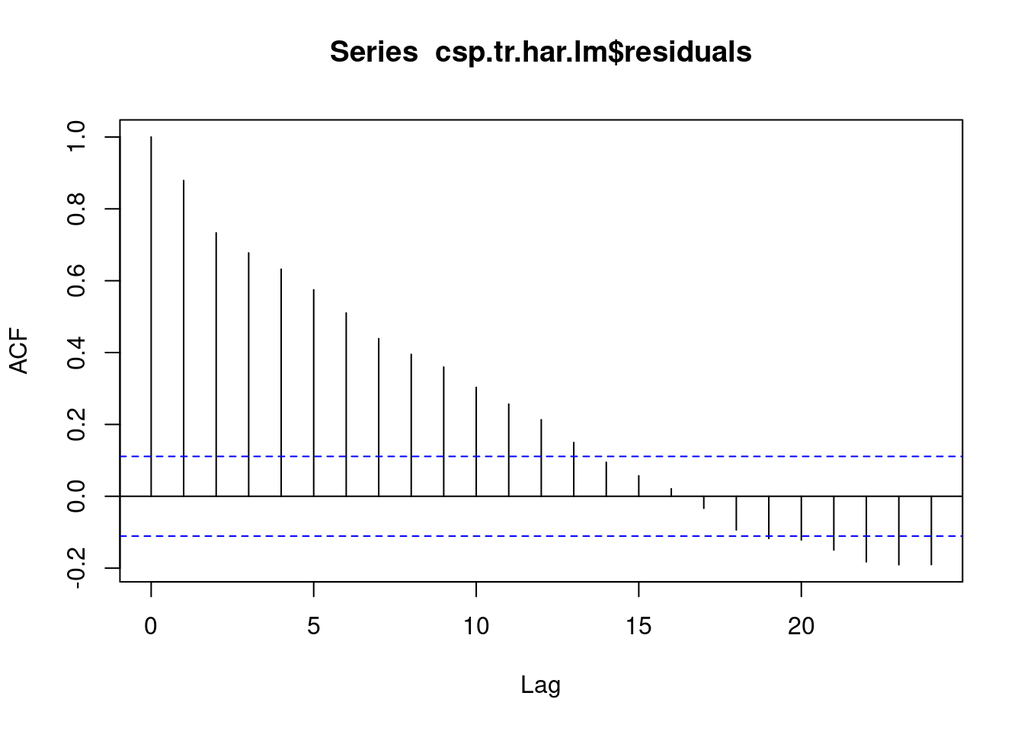

```r
acf(csp.tr.har.lm$residuals)
```

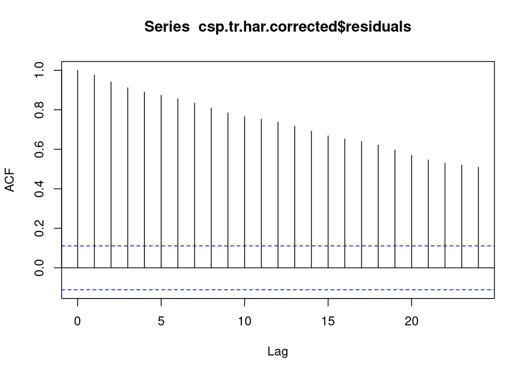

```r
acf(csp.tr.har.corrected$residuals)
```

There is still a ton of structure between both models.

Both of these models, like the factor model, will need their residuals to be fitted with an ARIMA model.

```r
csp.tr.har.lm.ar = auto.arima(csp.tr.har.lm$residuals)
csp.tr.har.lm.ar
```

```
## Series: csp.tr.har.lm$residuals
## ARIMA(1,0,4) with zero mean
##
## Coefficients:
##          ar1     ma1      ma2      ma3     ma4
##       0.9188  0.8080  -0.4260  -0.1805  0.1982
## s.e.  0.0355  0.0655   0.1008   0.0910  0.0585
##
## sigma^2 estimated as 0.01379:  log likelihood=225.71
## AIC=-439.42   AICc=-439.15   BIC=-416.96
```

We got an arima model of (1,0,4) for the power predictors linear model

Lets look at the remaining structure.

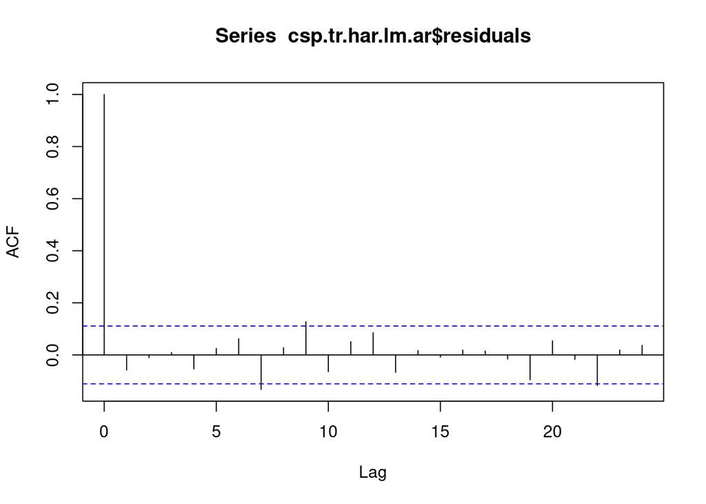

```r
acf(csp.tr.har.lm.ar$residuals)
```

There is possibly a tiny bit of structure still left in this, but it looks fine

Time for the other one

```r
csp.tr.har.corrected.ar = auto.arima(csp.tr.har.corrected$residuals)
csp.tr.har.corrected.ar
```

```
## Series: csp.tr.har.corrected$residuals
## ARIMA(4,2,3)
##
## Coefficients:
##           ar1      ar2      ar3      ar4     ma1      ma2      ma3
##       -0.2340  -0.5749  -0.1170  -0.4369  0.0662  -0.7541  -0.2463
## s.e.   0.1226   0.0612   0.0677   0.0595  0.1316   0.0459   0.1166
##
## sigma^2 estimated as 0.01597:  log likelihood=202.13
## AIC=-388.26   AICc=-387.78   BIC=-358.36
```

With this, we got an arima model of (4,2,3), which is a much higher order than the other harmonic model.

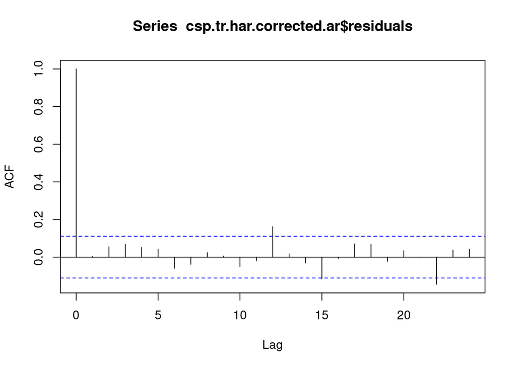

```r
acf(csp.tr.har.corrected.ar$residuals)
```

The correlogram of the residuals for this model looks better, however.

Now we will predict with these two harmonic models and their respective arima models.

First is the powered predictor harmonic model:

Standardize Time

```r
new.t = time(ts(start=2014,end=c(2016,12),fr=12))
TIME = (new.t-mean(time(csp.tr))) / sd(time(csp.tr))
```

Generating Harmonic models to be predicted onto with 3 years

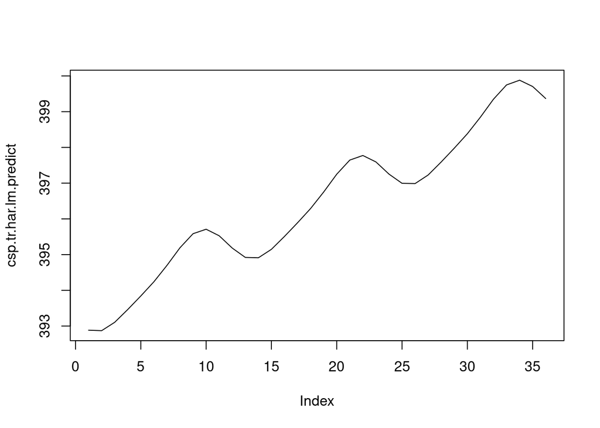

```r
SIN = COS = matrix(nrow=length(new.t),ncol=6)
for(i in 1:6){
  COS[,i]=cos(2*pi*i*new.t)
  SIN[,i]=sin(2*pi*i*new.t)
}
har.lm.df = data.frame(TIME = TIME,`TIME^2`=TIME^2,
                       `TIME^2`=TIME^3,`TIME^2`=TIME^4,
                       C1=COS[,1],S1=SIN[,1],
                       C2=COS[,2],S2=SIN[,2],
                       S3=SIN[,3])

csp.tr.har.lm.predict = predict(csp.tr.har.lm,har.lm.df)
plot(csp.tr.har.lm.predict,type='l')
```

```r
csp.tr.har.lm.predict.ts = ts(csp.tr.har.lm.predict,start=2014,fr=12)
csp.tr.har.lm.predict.ts
```

```
##           Jan      Feb      Mar      Apr      May      Jun      Jul      Aug
## 2014 392.8836 392.8706 393.1048 393.4631 393.8423 394.2387 394.6969 395.1922
## 2015 394.9208 394.9106 395.1475 395.5087 395.8908 396.2901 396.7513 397.2497
## 2016 396.9946 396.9878 397.2282 397.5930 397.9787 398.3817 398.8467 399.3489
##           Sep      Oct      Nov      Dec
## 2014 395.5848 395.7097 395.5264 395.1823
## 2015 397.6455 397.7736 397.5934 397.2527
## 2016 399.7486 399.8807 399.7046 399.3679
```

Now we predict with our AR and then combine

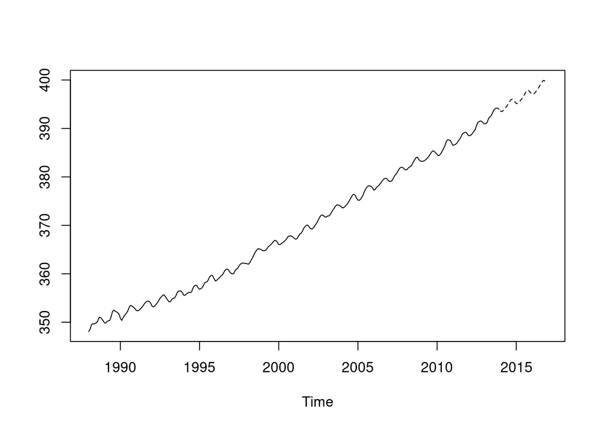

```r
csp.tr.har.lm.ar.predict = predict(csp.tr.har.lm.ar,n.ahead=36)
csp.tr.har.pred_lm = ts((csp.tr.har.lm.predict+csp.tr.har.lm.ar.predict$pred),st=2014,fr=12)
ts.plot(cbind(csp.tr,csp.tr.har.pred_lm),lty=1:2)
```

Time for the other harmonic model that contains correct predictors from GLS We already have standardized TIME and new.t for this

Generating Harmonic models to be predicted onto with 3 years

```r
SIN = COS = matrix(nrow=length(new.t),ncol=6)
for(i in 1:6){
  COS[,i]=cos(2*pi*i*new.t)
  SIN[,i]=sin(2*pi*i*new.t)
}
```

Create corrected new dataframe

```r
har.lm.df = data.frame(TIME = TIME,C1=COS[,1],S1=SIN[,1])
```

Predict with correct model

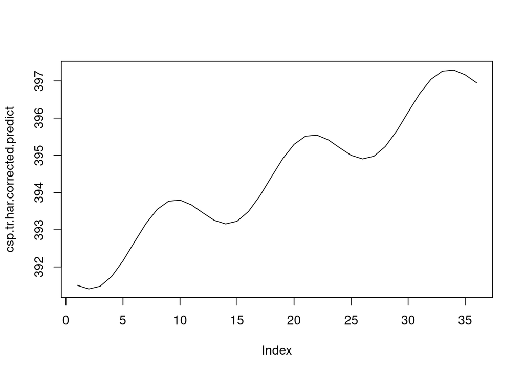

```r
csp.tr.har.corrected.predict = predict(csp.tr.har.corrected,har.lm.df)
plot(csp.tr.har.corrected.predict,type='l')
```

```r
csp.tr.har.corrected.predict.ts = ts(csp.tr.har.corrected.predict,start=2014,fr=12)
```

Now we predict with our AR and then combine

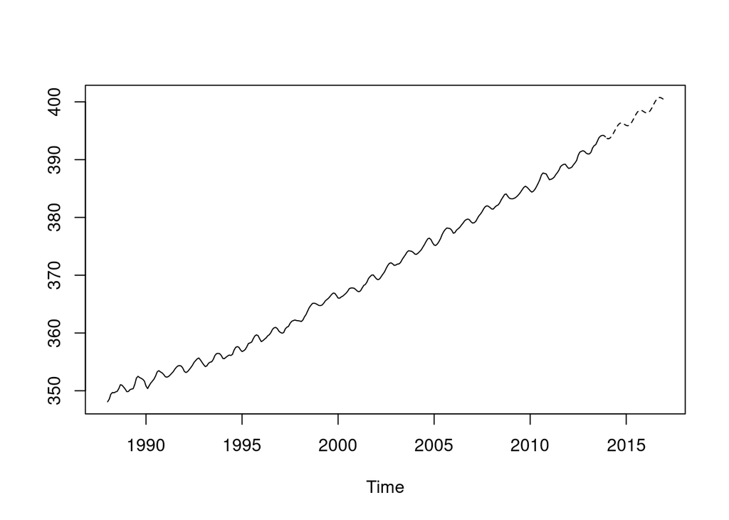

```r
csp.tr.har.corrected.ar.predict = predict(csp.tr.har.corrected.ar,n.ahead=36)
csp.tr.har.pred_corrected = ts((csp.tr.har.corrected.predict+
                               csp.tr.har.corrected.ar.predict$pred),
                               st=2014,fr=12)
ts.plot(cbind(csp.tr,csp.tr.har.pred_corrected),lty=1:2)
```

Both Harmonic models have been fitted, lets move onto another model.

FITING MODELS: HOLT WINTERS MODEL

There is seasonality and trend in the data, so we will not set any to F and let R decide alpha, gamma, and beta. We will also fit the model to 3 years into the future.

```r
csp.tr.hw = hw(csp.tr,h=36)
```

Now we predict while modifying the holt winters forecast class

```r
csp.tr.hw.pred = ts(as.numeric(unlist(csp.tr.hw[2])),st=2014,fr=12)
csp.tr.hw.pred
```

```
##           Jan      Feb      Mar      Apr      May      Jun      Jul      Aug
## 2014 393.6617 393.7441 394.0597 394.5351 394.9874 395.3938 395.9080 396.4214
## 2015 396.0669 396.1493 396.4649 396.9403 397.3925 397.7990 398.3132 398.8266
## 2016 398.4721 398.5545 398.8701 399.3455 399.7977 400.2041 400.7184 401.2318
##           Sep      Oct      Nov      Dec
## 2014 396.6957 396.7876 396.6470 396.3551
## 2015 399.1009 399.1928 399.0522 398.7603
## 2016 401.5061 401.5980 401.4573 401.1655
```

Time to look at the residuals

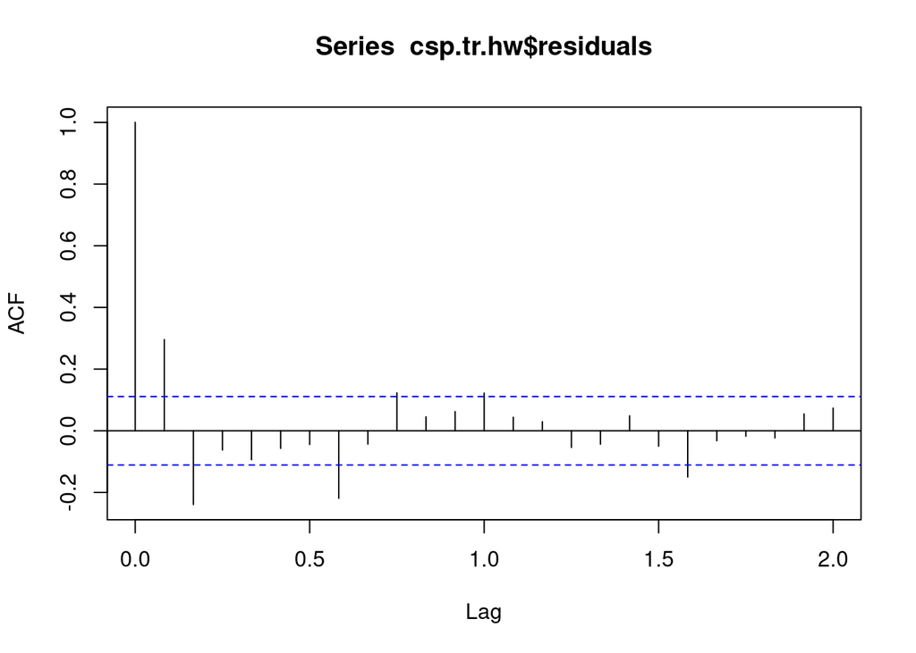

```r
acf(csp.tr.hw$residuals)
```

There is actually a bit of structure. At this point, I would say that this model is not very practical, but we will let the MSE decide

Get the fitted model

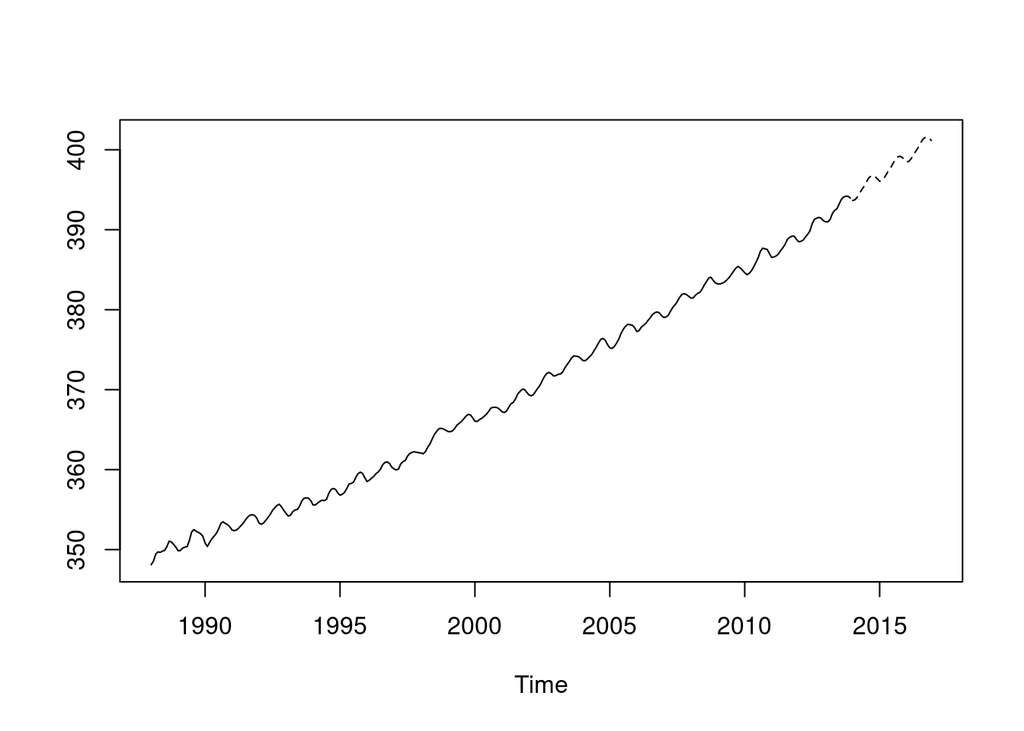

```r
ts.plot(cbind(csp.tr,csp.tr.hw.pred),lty=1:2)
```

Looks pretty good.

FITTING MODEL: SARIMA MODEL We will now just fit our Time Series data to a SARIMA model

```r
csp.tr.am = auto.arima(csp.tr)
csp.tr.am
```

```
## Series: csp.tr
## ARIMA(4,1,2)(2,1,2)[12]
##
## Coefficients:
##           ar1      ar2      ar3      ar4     ma1     ma2    sar1     sar2
##       -0.4317  -0.4487  -0.0189  -0.2256  1.2274  0.3725  0.7200  -0.1336
## s.e.   0.1643   0.0701   0.0790   0.0715  0.1626  0.1455  0.3913   0.0836
##          sma1    sma2
##       -1.5235  0.5721
## s.e.   0.3886  0.3532
##
## sigma^2 estimated as 0.02004:  log likelihood=202.02
## AIC=-382.05   AICc=-381.13   BIC=-341.34
```

When we fit the model to auto arima, we get these orders (4,1,2)(2,1,2)

Lets see how well this SARIMA model can explain the auto correlations

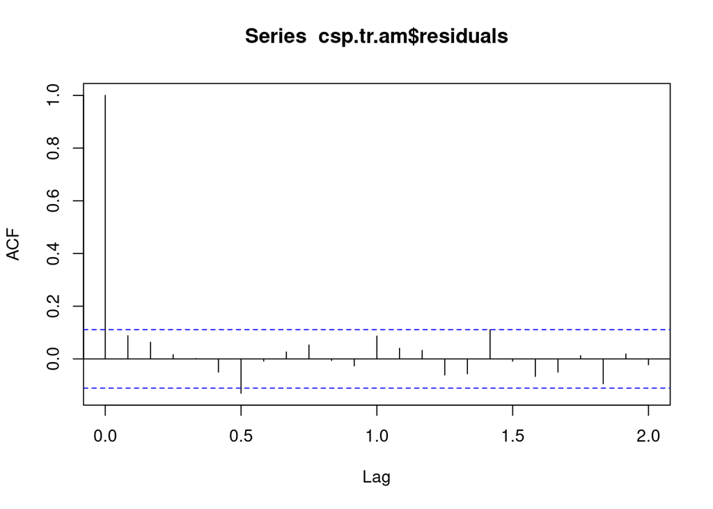

```r
acf(csp.tr.am$residuals)
```

Actually very well, lag 6 and 12 are very close, but I would say that this model succeeded.

Now lets check the confidence intervals of the coefficients of this model real quick

```r
csp.tr.am
```

```
## Series: csp.tr
## ARIMA(4,1,2)(2,1,2)[12]
##
## Coefficients:
##           ar1      ar2      ar3      ar4     ma1     ma2    sar1     sar2
##       -0.4317  -0.4487  -0.0189  -0.2256  1.2274  0.3725  0.7200  -0.1336
## s.e.   0.1643   0.0701   0.0790   0.0715  0.1626  0.1455  0.3913   0.0836
##          sma1    sma2
##       -1.5235  0.5721
## s.e.   0.3886  0.3532
##
## sigma^2 estimated as 0.02004:  log likelihood=202.02
## AIC=-382.05   AICc=-381.13   BIC=-341.34
```

Time to predict

```r
csp.tr.am.pred = predict(csp.tr.am,n.ahead=36)
csp.tr.am.pred$pred
```

```
##           Jan      Feb      Mar      Apr      May      Jun      Jul      Aug
## 2014 393.6351 393.5932 393.8254 394.2233 394.5992 394.9384 395.4146 395.9348
## 2015 395.6034 395.5854 395.7966 396.1413 396.5036 396.8688 397.3465 397.8582
## 2016 397.5007 397.4871 397.6960 398.0440 398.4055 398.7715 399.2627 399.7795
##           Sep      Oct      Nov      Dec
## 2014 396.2441 396.3275 396.2224 395.9061
## 2015 398.1675 398.2514 398.1288 397.7965
## 2016 400.0849 400.1699 400.0492 399.7165
```

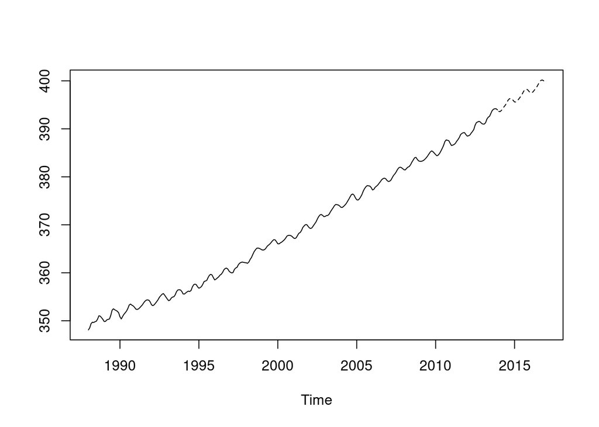

```r
ts.plot(cbind(csp.tr,csp.tr.am.pred$pred),lty=1:2)
```

Again, looks good.

TESTING MODELS’ PREDICTION PERFORMANCE

Now we want to test the models on the test time series set that we set aside in the beginning. We will use the MAD and MSE to compare models with each other.

MAD ~ Mean Absolute Differences MSE ~ Mean Square Error

MAD First

```r
# Factor LM
ind.MAD = mean(abs(csp.test-csp.tr.ind.pred))
# Harmonic with power predictors
har.lm.MAD = mean(abs(csp.test-csp.tr.har.pred_lm))
# Harmonic corrected
har.corrected.MAD = mean(abs(csp.test-csp.tr.har.pred_corrected))
# Holt Winters
hw.MAD = mean(abs(csp.test-csp.tr.hw.pred))
# SARIMA model
am.MAD = mean(abs(csp.test-csp.tr.am.pred$pred))

measures = data.frame(MAD = c(ind.MAD,har.lm.MAD,
                              har.corrected.MAD,hw.MAD,am.MAD))
rownames(measures)=(c('IND','HAR_L','HAR_C','HW','AM'))
measures
```

```
##             MAD
## IND   0.3945448
## HAR_L 0.8526554
## HAR_C 0.4439792
## HW    0.5106723
## AM    0.6738781
```

Now we will measure the MSE for each model

```r
# Factor LM
ind.MSE = mean((csp.test-csp.tr.ind.pred)^2)
# Harmonic with power predictors
har.lm.MSE = mean((csp.test-csp.tr.har.pred_lm)^2)
# Harmonic corrected
har.corrected.MSE = mean((csp.test-csp.tr.har.pred_corrected)^2)
# Holt Winters
hw.MSE = mean((csp.test-csp.tr.hw.pred)^2)
# SARIMA
am.MSE = mean((csp.test-csp.tr.am.pred$pred)^2)

measures = data.frame(MAD = c(ind.MAD,har.lm.MAD,
                              har.corrected.MAD,hw.MAD,am.MAD),
                      MSE = c(ind.MSE,har.lm.MSE,
                              har.corrected.MSE,hw.MSE,am.MSE))
rownames(measures)=(c('IND','HAR_L','HAR_C','HW','AM'))
measures
```

```
##             MAD       MSE
## IND   0.3945448 0.2157021
## HAR_L 0.8526554 1.2698628
## HAR_C 0.4439792 0.3267223
## HW    0.5106723 0.3101828
## AM    0.6738781 0.8020643
```

Now which model do I choose…

It seemed like using a GLS was the right move because both the Indicator and corrected harmonic models -which used gls to correct- have very low MAD and MSE Score unlike the uncorrected Harmonic model Har_L

The Linear Regressive Indicator Model seems to perform the best in both metrics, so lets now Refit the Indicator Linear model to the full dataset and predict forward 3 years.

REFITTING WITH FULL DATASET

```r
TIME = 1:length(csp.ts)
Seas = cycle(csp.ts)
```

We will predict with the same variables we had for our best model

```r
csp.lm = lm(csp.ts~0+TIME+I(TIME^2)+factor(Seas))
```

Lets run an auto arima

```r
csp.am = auto.arima(csp.lm$residuals)
csp.am
```

```
## Series: csp.lm$residuals
## ARIMA(4,1,3)
##
## Coefficients:
##           ar1      ar2      ar3      ar4     ma1     ma2     ma3
##       -0.7267  -0.9507  -0.1890  -0.3404  1.5165  1.1301  0.4464
## s.e.   0.1808   0.1466   0.0845   0.0664  0.1877  0.2729  0.1290
##
## sigma^2 estimated as 0.01296:  log likelihood=264
## AIC=-512   AICc=-511.57   BIC=-481.21
```

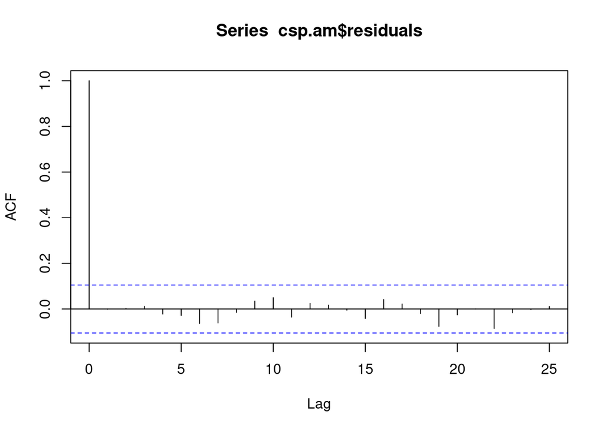

```r
acf(csp.am$residuals)
```

Looks really good!

We will now predict!

```r
length(TIME)
```

```
## [1] 348
```

New time is from (length old TIME+1) >to> old TIME + (frequency * years ahead)

```r
new.t = 349:(348+12*3)
```

Create dataframe of TIME and names of all predictors

```r
names(csp.lm$coefficients)
```

```
##  [1] "TIME"           "I(TIME^2)"      "factor(Seas)1"  "factor(Seas)2"
##  [5] "factor(Seas)3"  "factor(Seas)4"  "factor(Seas)5"  "factor(Seas)6"
##  [9] "factor(Seas)7"  "factor(Seas)8"  "factor(Seas)9"  "factor(Seas)10"
## [13] "factor(Seas)11" "factor(Seas)12"
```

```r
new.df = data.frame(TIME=new.t,
                    `I(TIME^2)`=new.t^2,
                    Seas=rep(1:12,3))
```

Changing names of the dataframe columns

```r
colnames(new.df)[1:2]=names(csp.lm$coefficients)[1:2]
colnames(new.df)
```

```
## [1] "TIME"      "I(TIME^2)" "Seas"
```

Now we run the prediction function for the LM model

```r
csp.lm.pred = predict(csp.lm,new.df)
```

We predict with the Arima model added to the LM predictions and creating a time series from them

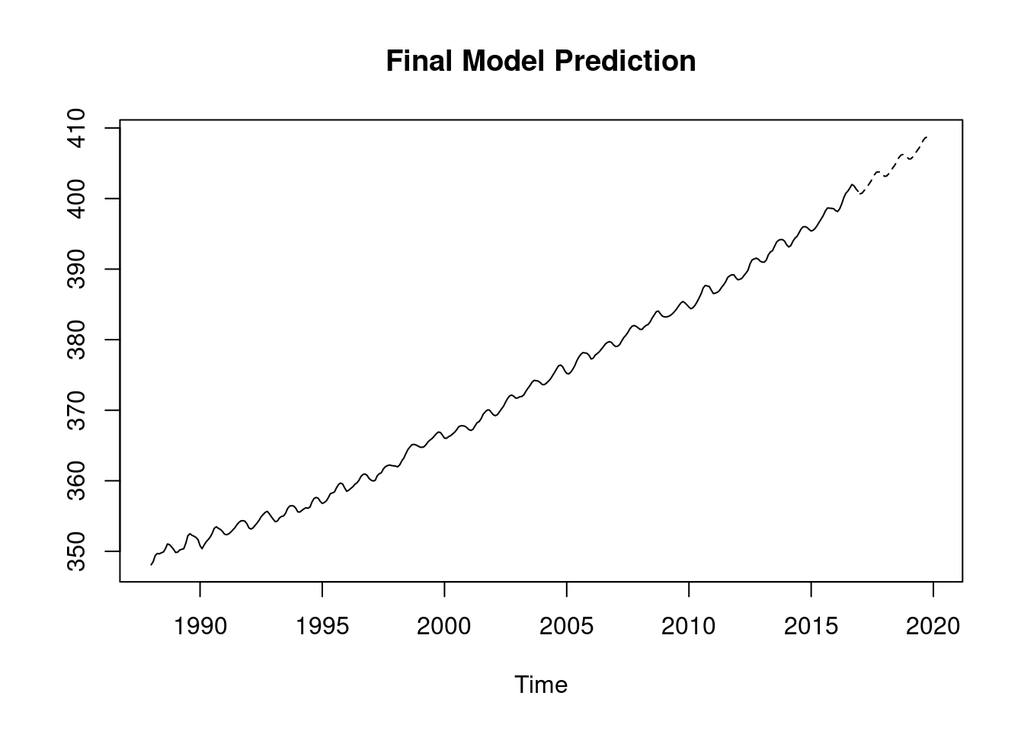

```r
csp.am.pred = predict(csp.am,n.ahead=36)
csp.prediction = ts(csp.lm.pred + csp.am.pred$pred,st=2017,fr=12)
ts.plot(cbind(csp.ts,csp.prediction),lty=1:2,main="Final Model Prediction")
```

This is our final model that we have chosen based off of its predictive performance on our last 3 years of data. This new prediction would now be used for educated business moves or scientific insight.